# Predicting the default probabilities

Aylin Mumcular

29 Mart 2018

## Explore

```r
head(d)
```

```
##   default student   balance    income
## 1      No      No  729.5265 44361.625
## 2      No     Yes  817.1804 12106.135
## 3      No      No 1073.5492 31767.139
## 4      No      No  529.2506 35704.494
## 5      No      No  785.6559 38463.496
## 6      No     Yes  919.5885  7491.559
```

```r
dim(d)
```

```
## [1] 10000     4
```

```r
summary(d)
```

```
##  default    student       balance           income
##  No :9667   No :7056   Min.   :   0.0   Min.   :  772
##  Yes: 333   Yes:2944   1st Qu.: 481.7   1st Qu.:21340
##                        Median : 823.6   Median :34553
##                        Mean   : 835.4   Mean   :33517
##                        3rd Qu.:1166.3   3rd Qu.:43808
##                        Max.   :2654.3   Max.   :73554
```

```r
d %>% count(default) %>%
  mutate(prop=n/sum(n))
```

```
## # A tibble: 2 x 3
##   default     n   prop
##   <fct>   <int>  <dbl>
## 1 No       9667 0.967
## 2 Yes       333 0.0333
```

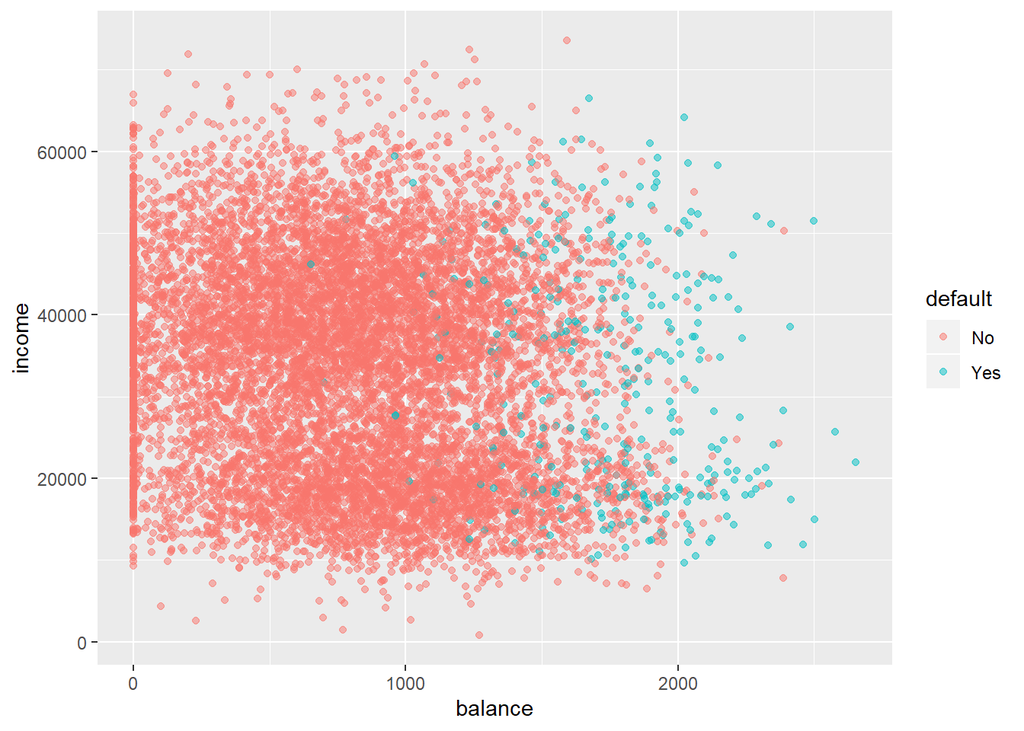

```r
d %>%
  ggplot(aes(balance,income))+
  geom_point(aes(col=default),alpha=0.5)
```

```r
d %>%
  count(default,student) %>%
  group_by(default) %>%
  mutate(prop=n/sum(n)) %>%
  select(-n) %>%
  spread(student,prop)
```

```
## # A tibble: 2 x 3
## # Groups:   default [2]
##   default    No   Yes
##   <fct>   <dbl> <dbl>
## 1 No      0.709 0.291
## 2 Yes     0.619 0.381
```

```r
d %>%
  count(default,student) %>%
  group_by(student) %>%
  mutate(prop=n/sum(n)) %>%
  select(-n) %>%
  spread(default,prop) #if you know someone is a student what's the likelihoood that this person is gonna default
```

```
## # A tibble: 2 x 3
## # Groups:   student [2]
##   student    No    Yes
##   <fct>   <dbl>  <dbl>
## 1 No      0.971 0.0292
## 2 Yes     0.957 0.0431
```

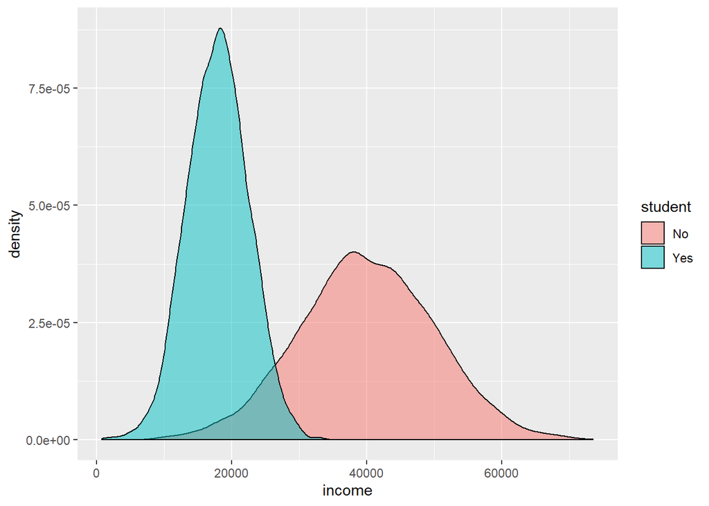

```r
d %>% ggplot(aes(income))+
  geom_density(aes(fill=student),alpha=0.5)
```

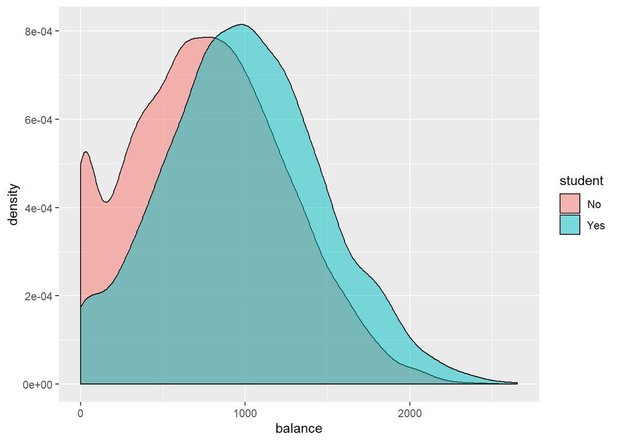

```r
d %>% ggplot(aes(balance))+
  geom_density(aes(fill=student),alpha=0.5)
```

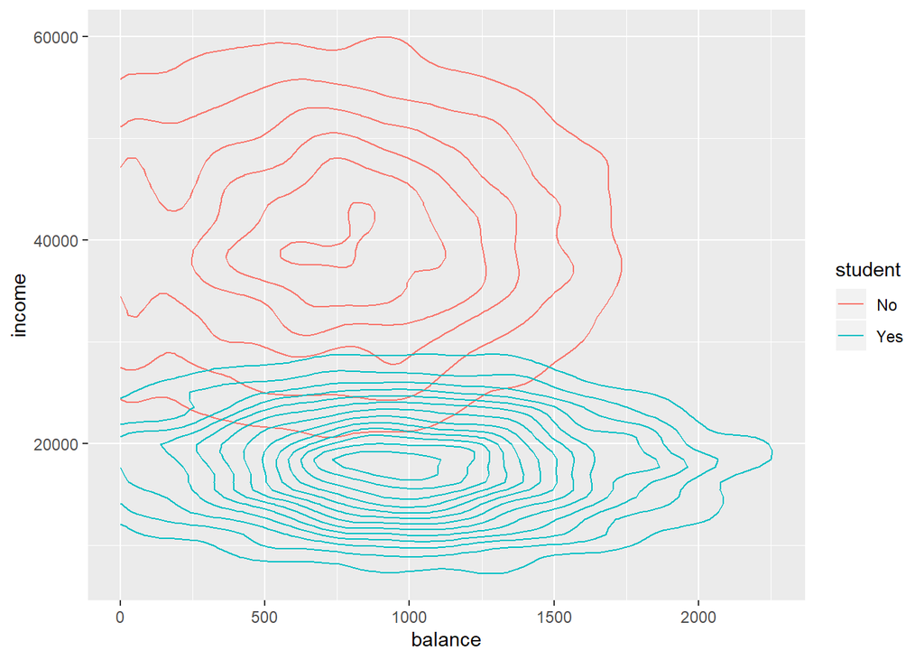

```r
d %>% ggplot(aes(balance,income))+
  geom_density2d(aes(col=student))
```

```r
#Students on average make less money than non-students. No relation between income and default. People with high balance tend to default more.
```

Fit a logistic regression to our default data.

$$p_i = \frac{e^{x_i^\top \beta}}{1+e^{x_i^\top \beta}}$$
Let’s glm() to find p_i in terms of inputs.

```r
d$default %>% levels()
```

```
## [1] "No"  "Yes"
```

```r
glmod <- glm(default~student+balance+income,d,family="binomial")
glmod
```

```
##
## Call:  glm(formula = default ~ student + balance + income, family = "binomial",
##     data = d)
##
## Coefficients:
## (Intercept)   studentYes      balance       income
##  -1.087e+01   -6.468e-01    5.737e-03    3.033e-06
##
## Degrees of Freedom: 9999 Total (i.e. Null);  9996 Residual
## Null Deviance:       2921
## Residual Deviance: 1572  AIC: 1580
```

Test the goodness of the fit of the current model. Using the asymptotic theory:

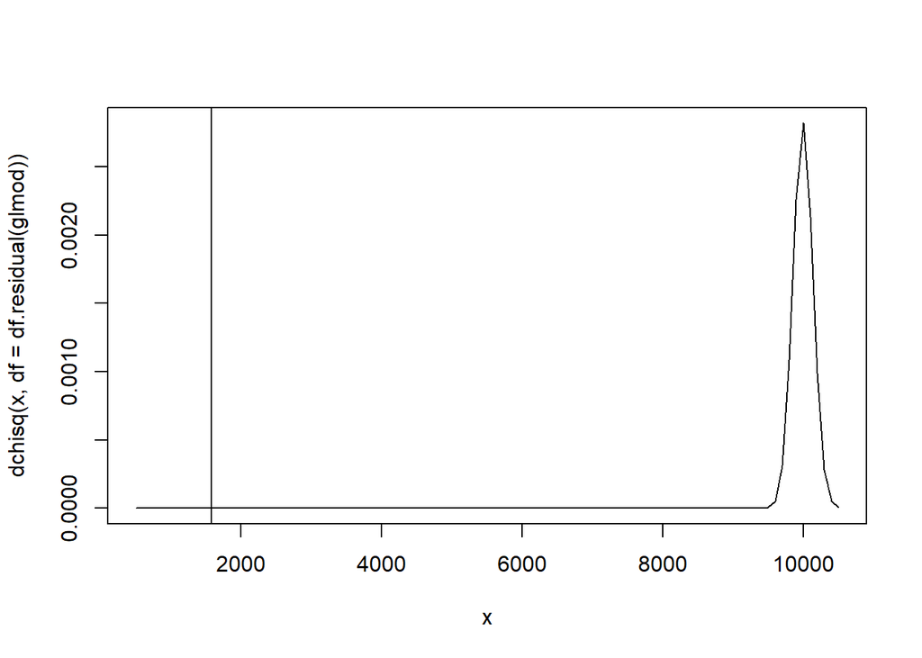

```r
curve(dchisq(x,df=df.residual(glmod)),xlim=c(500,10500))
abline(v=deviance(glmod))
```

```r
pvalue <- pchisq(deviance(glmod),
                 df=df.residual(glmod),lower.tail=FALSE)
pvalue
```

```
## [1] 1
```

This is overly optimistic, because chi-square approximation to deviance is not good for the logistic regression version of GLM. Instead let’s calculate the null distribution of the deviance. Distribution when the null hypothesis is correct. (Namely, distribution of deviance under $H_0: \text{the current model is correct}$ using bootstrapping.)

```r
glmod
```

```
##
## Call:  glm(formula = default ~ student + balance + income, family = "binomial",
##     data = d)
##
## Coefficients:
## (Intercept)   studentYes      balance       income
##  -1.087e+01   -6.468e-01    5.737e-03    3.033e-06
##
## Degrees of Freedom: 9999 Total (i.e. Null);  9996 Residual
## Null Deviance:       2921
## Residual Deviance: 1572  AIC: 1580
```

```r
repl <- 1000
sim_res <- simulate(glmod,repl) #simulates response. Cooked my own data
dim(sim_res)
```

```
## [1] 10000  1000
```

```r
set.seed(545)
deviance_array <- NULL
for(i in seq(repl)){ #get rid of original data, plug cooked ones and refit the model
  d.sim <- mutate(d,default=sim_res[,i]) #replace original ith data
  glmod.sim <- update(glmod,data=d.sim)
  deviance_array[i] <- deviance(glmod.sim)
}

glmod
```

```
##
## Call:  glm(formula = default ~ student + balance + income, family = "binomial",
##     data = d)
##
## Coefficients:
## (Intercept)   studentYes      balance       income
##  -1.087e+01   -6.468e-01    5.737e-03    3.033e-06
##
## Degrees of Freedom: 9999 Total (i.e. Null);  9996 Residual
## Null Deviance:       2921
## Residual Deviance: 1572  AIC: 1580
```

```r
head(deviance_array)
```

```
## [1] 1621.578 1598.617 1555.899 1601.408 1705.115 1520.832
```

```r
deviance(glmod)
```

```
## [1] 1571.545
```

```r
i=1
```

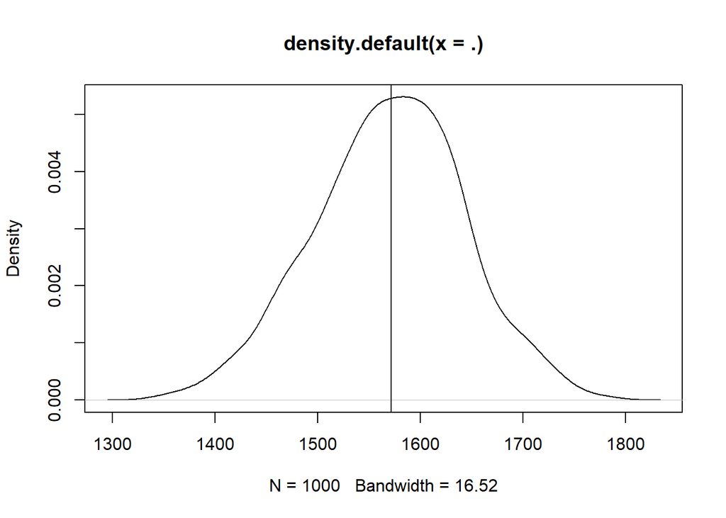

```r
deviance_array %>% density %>% plot  #hat distr
abline(v=deviance(glmod))
```

```r
pval <- mean(deviance_array>deviance(glmod))
pval
```

```
## [1] 0.512
```

Because the pvalue (0.512) is greater than 0.05, we cannot reject the null hypo $H_0: \text{the current model is correct}$ at 5% or less % of level of significance. Our level is fitting fine.

```r
predict(glmod,type="response")[1:3]
```

```
##           1           2           3
## 0.001428724 0.001122204 0.009812272
```

##Important variables?

```r
glmod %>% coef
```

```
##   (Intercept)    studentYes       balance        income
## -1.086905e+01 -6.467758e-01  5.736505e-03  3.033450e-06
```

Does being a non-student applicant increase the credit default? Test

```r
vcov(glmod)
```

```
##               (Intercept)    studentYes       balance        income
## (Intercept)  2.423155e-01 -5.320182e-02 -8.223081e-05 -2.670752e-06
## studentYes  -5.320182e-02  5.581526e-02 -9.733078e-06  1.513597e-06
## balance     -8.223081e-05 -9.733078e-06  5.377507e-08 -2.671530e-11
## income      -2.670752e-06  1.513597e-06 -2.671530e-11  6.728290e-11
```

z values are reported in the summary of the fitted model.

```r
summary(glmod)  #Being a student plays an important role, significant due to p value of 0.006
```

```
##
## Call:
## glm(formula = default ~ student + balance + income, family = "binomial",
##     data = d)
##
## Deviance Residuals:
##     Min       1Q   Median       3Q      Max
## -2.4691  -0.1418  -0.0557  -0.0203   3.7383
##
## Coefficients:
##               Estimate Std. Error z value Pr(>|z|)
## (Intercept) -1.087e+01  4.923e-01 -22.080  < 2e-16 ***
## studentYes  -6.468e-01  2.363e-01  -2.738  0.00619 **
## balance      5.737e-03  2.319e-04  24.738  < 2e-16 ***
## income       3.033e-06  8.203e-06   0.370  0.71152
## ---
## Signif. codes:  0 '***' 0.001 '**' 0.01 '*' 0.05 '.' 0.1 ' ' 1
##
## (Dispersion parameter for binomial family taken to be 1)
##
##     Null deviance: 2920.6  on 9999  degrees of freedom
## Residual deviance: 1571.5  on 9996  degrees of freedom
## AIC: 1579.5
##
## Number of Fisher Scoring iterations: 8
```

Alternatively, I can test with **likelihood-ratio** test

```r
anova(
  update(glmod,.~.-student-income),
  glmod, test="Chi")
```

```
## Analysis of Deviance Table
##
## Model 1: default ~ balance
## Model 2: default ~ student + balance + income
##   Resid. Df Resid. Dev Df Deviance  Pr(>Chi)
## 1      9998     1596.5
## 2      9996     1571.5  2   24.907 3.904e-06 ***
## ---
## Signif. codes:  0 '***' 0.001 '**' 0.01 '*' 0.05 '.' 0.1 ' ' 1
```

```r
anova(
  update(glmod,.~.-student),
  glmod, test="Chi")
```

```
## Analysis of Deviance Table
##
## Model 1: default ~ balance + income
## Model 2: default ~ student + balance + income
##   Resid. Df Resid. Dev Df Deviance Pr(>Chi)
## 1      9997     1579.0
## 2      9996     1571.5  1   7.4214 0.006445 **
## ---
## Signif. codes:  0 '***' 0.001 '**' 0.01 '*' 0.05 '.' 0.1 ' ' 1
```

```r
anova(
  update(glmod,.~.-income),
  #Statistically cannot find sufficient evidence to suggest that income is important.
  glmod, test="Chi")
```

```
## Analysis of Deviance Table
##
## Model 1: default ~ student + balance
## Model 2: default ~ student + balance + income
##   Resid. Df Resid. Dev Df Deviance Pr(>Chi)
## 1      9997     1571.7
## 2      9996     1571.5  1  0.13677   0.7115
```

**Is the effect of balance equal to 6(10^-3) H0: Beta_balance=6(10^-3)

Test $H_0:\beta_\mathrm{balance}=0.006$.

```r
#Big model logit(pi)=beta0+beta1 studentYes+beta2 balance+beta3 income
#Under H0: logit(pi)=beta0+beta1 studentYes+6(10^-3) balance+beta3 income

small <- glm(default~student+income+offset(6e-3*balance),d,family="binomial")

anova(small,glmod,test="LRT") #LRT is the same with Chi
```

```
## Analysis of Deviance Table
##
## Model 1: default ~ student + income + offset(0.006 * balance)
## Model 2: default ~ student + balance + income
##   Resid. Df Resid. Dev Df Deviance Pr(>Chi)
## 1      9997     1572.8
## 2      9996     1571.5  1   1.2487   0.2638
```

```r
#we are unable to reject null hypo. That estimate is consistent with the data.
```

Confidence intervals for the effect sizes

```r
#confidence interval

confint(glmod, level=0.80)
```

```
##                      10 %          90 %
## (Intercept) -1.151059e+01 -1.024851e+01
## studentYes  -9.491516e-01 -3.434066e-01
## balance      5.444882e-03  6.039458e-03
## income      -7.479015e-06  1.355037e-05
```

**Do the effects of balance and income on default risk the same? (beta_balance and beta_income) H0: Beta_balance=Beta_income=Beta_common

logit pi=beta_0+beta_student studentYes+beta_common (balance+income)

Test $H_0:\beta_\mathrm{balance}=\beta_\mathrm{income}$.

```r
small <- glm(default~student+I(balance+income),d,family="binomial")

d2 <- mutate(d,common=balance+income) #another way

small2 <- glm(default~student+common,d2,family="binomial")

anova(small2,glmod,test="Chi") #Reject and conclude that their effects are not the same.
```

```
## Analysis of Deviance Table
##
## Model 1: default ~ student + common
## Model 2: default ~ student + balance + income
##   Resid. Df Resid. Dev Df Deviance  Pr(>Chi)
## 1      9997     2899.3
## 2      9996     1571.5  1   1327.7 < 2.2e-16 ***
## ---
## Signif. codes:  0 '***' 0.001 '**' 0.01 '*' 0.05 '.' 0.1 ' ' 1
```

```r
anova(small,glmod,test="Chi")
```

```
## Analysis of Deviance Table
##
## Model 1: default ~ student + I(balance + income)
## Model 2: default ~ student + balance + income
##   Resid. Df Resid. Dev Df Deviance  Pr(>Chi)
## 1      9997     2899.3
## 2      9996     1571.5  1   1327.7 < 2.2e-16 ***
## ---
## Signif. codes:  0 '***' 0.001 '**' 0.01 '*' 0.05 '.' 0.1 ' ' 1
```

```r
step(glmod)
```

```
## Start:  AIC=1579.54
## default ~ student + balance + income
##
##           Df Deviance    AIC
## - income   1   1571.7 1577.7
## <none>         1571.5 1579.5
## - student  1   1579.0 1585.0
## - balance  1   2907.5 2913.5
##
## Step:  AIC=1577.68
## default ~ student + balance
##
##           Df Deviance    AIC
## <none>         1571.7 1577.7
## - student  1   1596.5 1600.5
## - balance  1   2908.7 2912.7
```

```
##
## Call:  glm(formula = default ~ student + balance, family = "binomial",
##     data = d)
##
## Coefficients:
## (Intercept)   studentYes      balance
##  -10.749496    -0.714878     0.005738
##
## Degrees of Freedom: 9999 Total (i.e. Null);  9997 Residual
## Null Deviance:       2921
## Residual Deviance: 1572  AIC: 1578
```

```r
drop1(glmod)
```

```
## Single term deletions
##
## Model:
## default ~ student + balance + income
##         Df Deviance    AIC
## <none>       1571.5 1579.5
## student  1   1579.0 1585.0
## balance  1   2907.5 2913.5
## income   1   1571.7 1577.7
```

Predictions of default probabilities

```r
invisible(predict(glmod))

logistic <- function(x) exp(x)/(1+exp(x))
invisible(predict(glmod) %>% logistic)

preds <- predict(glmod,type="response")


methods("predict")
```

```
##  [1] predict.ar*                predict.Arima*
##  [3] predict.arima0*            predict.glm
##  [5] predict.glmmPQL*           predict.gls*
##  [7] predict.gnls*              predict.HoltWinters*
##  [9] predict.lda*               predict.lm
## [11] predict.lme*               predict.lmList*
## [13] predict.loess*             predict.lqs*
## [15] predict.mca*               predict.mlm*
## [17] predict.nlme*              predict.nls*
## [19] predict.polr*              predict.poly*
## [21] predict.ppr*               predict.prcomp*
## [23] predict.princomp*          predict.qda*
## [25] predict.rlm*               predict.smooth.spline*
## [27] predict.smooth.spline.fit* predict.StructTS*
## see '?methods' for accessing help and source code
```

The misclassification error is minimized by the Bayes rule which classifies someone as defaulting if predicted default prob şs greater than or equal to 0.5

```r
cls <- levels(d$default)[1+(preds>=0.5)]
```

Confusion table

```r
tbl <- table(obs=d$default,preds=cls)

tbl %>% prop.table %>% diag %>% sum %>% {1-.}
```

```
## [1] 0.0268
```

```r
tbl %>% prop.table(1)  #almost 70% of people misclassified. It cannot identify risky people very well.
```

```
##      preds
## obs            No         Yes
##   No  0.995862212 0.004137788
##   Yes 0.684684685 0.315315315
```

```r
table(d$default) %>% prop.table()
```

```
##
##     No    Yes
## 0.9667 0.0333
```

```r
cls2 <- levels(d$default)[1+(preds>=0.1)]

tbl2 <- table(obs=d$default,preds=cls2)

tbl2 %>% prop.table %>% diag %>% sum %>% {1-.}
```

```
## [1] 0.0645
```

```r
tbl2 %>% prop.table(1)
```

```
##      preds
## obs           No        Yes
##   No  0.94207096 0.05792904
##   Yes 0.25525526 0.74474474
```

Cross-validated (Alternative to AIC, BIC, ANOVA. You can use this method to compare models and decide which variables to keep in the model) misclassification and false negative rates

```r
#shuffle the data to avoid data of the same kind.
nfold <- 10
set.seed(451)
fold.id <- rep(1:10,len=nrow(d)) %>% sample
table(fold.id)
```

```
## fold.id
##    1    2    3    4    5    6    7    8    9   10
## 1000 1000 1000 1000 1000 1000 1000 1000 1000 1000
```

```r
error.rate <- rep(NA,nfold)
fn.rate <- rep(NA,nfold)



for (i in seq(nfold)) {


  glmod.train <- glm(default~.,data=d[fold.id!=i,],
                     family="binomial")
  preds <- predict(glmod.train,newdata=d[fold.id==i,],
                   type="response")

  cls <- c("No","Yes")[1+(preds>=.5)] #estimate error rate on unseen data

  cnfsn.tbl <- table(obs=d[fold.id==i,"default"],
                     preds=cls)   #confusion table
  error.rate[i] <- prop.table(cnfsn.tbl) %>% diag %>% sum %>% {1-.} #misclassification rate

  fn.rate[i] <- prop.table(cnfsn.tbl,1)["Yes","No"] #observed yes predicted no
}

m <- error.rate %>% mean
s <- error.rate %>% sd

#95% CI for error rate on the unseen data/generalization error rate

m+c(-1,1)*s*1.96 #alpha=0.05  , m+(c(-1,1))*qnorm(1-alpha/2)*s
```

```
## [1] 0.01658758 0.03741242
```

```r
m2 <- fn.rate %>% mean
s2 <- fn.rate %>% sd

#95% CI for false negative rate on the unseen data

m2+c(-1,1)*s2*1.96
```

```
## [1] 0.5749166 0.7892307
```

#Calculate ROC and AUC

```r
glmod
```

```
##
## Call:  glm(formula = default ~ student + balance + income, family = "binomial",
##     data = d)
##
## Coefficients:
## (Intercept)   studentYes      balance       income
##  -1.087e+01   -6.468e-01    5.737e-03    3.033e-06
##
## Degrees of Freedom: 9999 Total (i.e. Null);  9996 Residual
## Null Deviance:       2921
## Residual Deviance: 1572  AIC: 1580
```

```r
ROC.df <- data_frame(class=d$default,p=fitted(glmod)) %>%  #probabilities
  arrange(desc(p)) %>% #sort this data. Highest p at the top, the one most likely to default
  mutate(NumTP=cumsum(class=="Yes")-(class=="Yes"),
         NumFP=cumsum(class=="No")-(class=="No"),
         TPR=NumTP/sum(class=="Yes"),
         FPR=NumFP/sum(class=="No"))   #NTP=Number of true positives. Anyone with a threshold of strictly greater than this number will be named as positive.
```

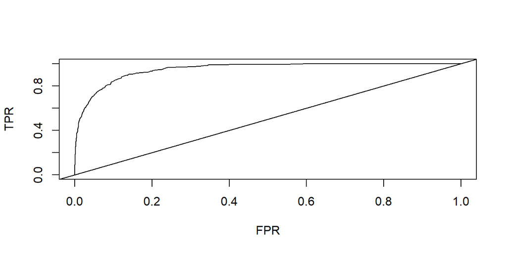

```r
plot(TPR~FPR,ROC.df,type="s")
abline(0,1)
```

```r
#how to calculate area under curve

TPR <- extract2(ROC.df,"TPR")
FPR <- extract2(ROC.df,"FPR")


AUC <- sum((tail(FPR,-1)-head(FPR,-1))*(head(TPR,-1)+tail(TPR,-1))/2)

AUC
```

```
## [1] 0.9494547
```

```r
ROC.df %>% mutate(dist=FPR^2+(1-TPR)^2) %>%
  arrange(dist)
```

```
## # A tibble: 10,000 x 7
##    class      p NumTP NumFP   TPR   FPR   dist
##    <fct>  <dbl> <int> <int> <dbl> <dbl>  <dbl>
##  1 No    0.0367   296  1213 0.889 0.125 0.0281
##  2 No    0.0355   297  1239 0.892 0.128 0.0281
##  3 No    0.0367   296  1214 0.889 0.126 0.0281
##  4 No    0.0355   297  1240 0.892 0.128 0.0281
##  5 No    0.0366   296  1215 0.889 0.126 0.0281
##  6 No    0.0355   297  1241 0.892 0.128 0.0282
##  7 No    0.0366   296  1216 0.889 0.126 0.0282
##  8 No    0.0354   297  1242 0.892 0.128 0.0282
##  9 No    0.0365   296  1217 0.889 0.126 0.0282
## 10 No    0.0365   296  1218 0.889 0.126 0.0282
## # ... with 9,990 more rows
```